# PSD analysis

```r
library(readr)
library(dplyr)
library(ggplot2)
library(tidyr)
library(PairedData)
library(cowplot)
select = dplyr::select
```

GGplot theme

```r
gtheme = theme_minimal() + theme_cowplot() +
  theme(text = element_text(size=20), axis.text = element_text(size=16))
```

```r
psddf = read_csv('psd_table_rest_cwt2.csv')
psddf$animal = as.factor(psddf$animal)
psddf$experiment = as.factor(psddf$experiment)
psddf$laser = as.factor(psddf$laser)
psddf$state = as.factor(psddf$state)
```

Add theta/slow variables to the obserservations

```r
firstpowcol = 6
nchan = 32
firstthetacol = firstpowcol + nchan
start_obs = ncol(psddf) + 1
psddf[,start_obs:(start_obs+nchan-1)] = psddf[,firstthetacol:(firstthetacol+nchan-1)]  / psddf[,firstpowcol:(firstthetacol-1)]
```

```
‘/’ not meaningful for factors
```

```r
colnames(psddf) = c(colnames(psddf)[1:(start_obs-1)], paste0(rep('pow_thetaoverslow_',nchan), format(1:nchan, width=2)))
```

Reorganize the data to have one row per channel

```r
gathered.psddf = gather(psddf, channel, opow_theta, starts_with('pow_theta_'))
gathered.psddf$channel_i = sapply(strsplit(gathered.psddf$channel, '_'), function(x) as.numeric(x[3]))
gathered.psddf$opow_slow = rep(0, nrow(gathered.psddf))
gathered.psddf$opow_slow_gamma = rep(0, nrow(gathered.psddf))
gathered.psddf$opow_med_gamma = rep(0, nrow(gathered.psddf))
gathered.psddf$opow_fast_gamma = rep(0, nrow(gathered.psddf))
gathered.psddf$opow_above_theta = rep(0, nrow(gathered.psddf))
gathered.psddf$opow_thetaoverslow = rep(0, nrow(gathered.psddf))
gathered.psddf$oswr_freq = rep(0, nrow(gathered.psddf))
gathered.psddf$oswr_powerhz = rep(0, nrow(gathered.psddf))
gathered.psddf$ohas_ripples = rep(0, nrow(gathered.psddf))
gathered.psddf$oripple_peakpow = rep(0, nrow(gathered.psddf))
gathered.psddf$oripple_dur = rep(0, nrow(gathered.psddf))
gathered.psddf$odom_freq = rep(0, nrow(gathered.psddf))
for (i in 1:nrow(gathered.psddf)) {
   ch = gathered.psddf$channel_i[i]

   col.id = paste0('pow_slow_', format(ch, width=2))
   gathered.psddf$opow_slow[i] = gathered.psddf[i, col.id]

   col.id = paste0('pow_slow_gamma_', format(ch, width=2))
   gathered.psddf$opow_slow_gamma[i] = gathered.psddf[i, col.id]

   col.id = paste0('pow_med_gamma_', format(ch, width=2))
   gathered.psddf$opow_med_gamma[i] = gathered.psddf[i, col.id]

   col.id = paste0('pow_fast_gamma_', format(ch, width=2))
   gathered.psddf$opow_fast_gamma[i] = gathered.psddf[i, col.id]

   col.id = paste0('pow_above_theta_', format(ch, width=2))
   gathered.psddf$opow_above_theta[i] = gathered.psddf[i, col.id]

   col.id = paste0('pow_thetaoverslow_', format(ch, width=2))
   gathered.psddf$opow_thetaoverslow[i] = gathered.psddf[i, col.id]

   col.id = paste0('swr_freq_', format(ch, width=2))
   gathered.psddf$oswr_freq[i] = gathered.psddf[i, col.id]

   col.id = paste0('swr_powerhz_', format(ch, width=2))
   gathered.psddf$oswr_powerhz[i] = gathered.psddf[i, col.id]

   col.id = paste0('has_ripples_', format(ch, width=2))
   gathered.psddf$ohas_ripples[i] = gathered.psddf[i, col.id]

   col.id = paste0('ripple_peakpow_', format(ch, width=2))
   gathered.psddf$oripple_peakpow[i] = gathered.psddf[i, col.id]

   col.id = paste0('ripple_dur_', format(ch, width=2))
   gathered.psddf$oripple_dur[i] = gathered.psddf[i, col.id]

   col.id = paste0('dom_freq_', format(ch, width=2))
   gathered.psddf$odom_freq[i] = gathered.psddf[i, col.id]
}
```

```r
gathered.psddf = dplyr::select(gathered.psddf,
                        c('animal', 'experiment', 'channel_i', 'time_sec', 'laser', 'state'),
                        starts_with('o'))
gathered.psddf = transform(gathered.psddf,
                           opow_slow = as.numeric(opow_slow),
                           opow_slow_gamma = as.numeric(opow_slow_gamma),
                           opow_med_gamma = as.numeric(opow_med_gamma),
                           opow_fast_gamma = as.numeric(opow_fast_gamma),
                           opow_above_theta = as.numeric(opow_above_theta),
                           opow_thetaoverslow = as.numeric(opow_thetaoverslow),
                           oswr_freq = as.numeric(oswr_freq),
                           oswr_powerhz = as.numeric(oswr_powerhz),
                           ohas_ripples = as.numeric(ohas_ripples),
                           oripple_peakpow = as.numeric(oripple_peakpow),
                           oripple_dur = as.numeric(oripple_dur),
                           odom_freq = as.numeric(odom_freq))
```

Revalue state factors to more descriptive values

```r
gathered.psddf$state = plyr::revalue(gathered.psddf$state,
                                     c('run'='active', 'isoflurane'='anesthetized', 'sleep'='asleep'))
```

Filter out data from channels which were noisy during trial (pow_theta==0)

```r
keep_experiments = gathered.psddf %>%
  group_by(experiment, channel_i) %>%
  summarise(mopow_theta = max(opow_theta)) %>%
  filter(mopow_theta != 0) %>%
  mutate(exp_desc = paste0(experiment, channel_i))
gathered.psddf = gathered.psddf %>%
  mutate(exp_desc = paste0(experiment, channel_i)) %>%
  filter(exp_desc %in% keep_experiments$exp_desc) %>%
  dplyr::select(-c(exp_desc))
```

```r
baseline_pow = gathered.psddf %>%
  filter(time_sec == 0) %>%
  group_by(experiment)
  #select(-c('animal', 'experiment', 'time_sec', 'laser', 'state'))

on_pow = gathered.psddf %>%
  filter(laser == 'ON') %>%
  group_by(experiment)
  #left_join(baseline_pow, by='experiment', suffix = c('','.base'))
  #merge(baseline_pow, by='experiment', suffixes=c('.x', '.base'))
changepct = on_pow
changepct[,7:ncol(on_pow)] = on_pow[,7:ncol(on_pow)] / baseline_pow[,7:ncol(on_pow)]
```

Albert: channels with biggest change

```r
channel.changepct = changepct %>%
  filter(animal == 'Albert') %>%
  group_by(channel_i) %>%
  summarise(mtheta = mean(opow_theta),
            mthetaoverslow = mean(opow_thetaoverslow, na.rm=TRUE),
            mslow = mean(opow_slow),
            mabovetheta = mean(opow_above_theta),
            mslowgamma = mean(opow_slow_gamma))
animals.swr_channels = group_by(gathered.psddf, animal, channel_i, state) %>%
  filter(state == 'asleep' & laser == 'OFF') %>%
  summarise( mswr_freq = mean(oswr_freq), mopow_theta = mean(opow_theta) ) %>%
  arrange(desc(mswr_freq)) %>%
  filter(mswr_freq > 0.15) %>%
  filter(mopow_theta != 0) %>%
  dplyr::select(animal, channel_i, mswr_freq)
best.swr_channels = animals.swr_channels %>%
  group_by(animal) %>%
  arrange(desc(mswr_freq)) %>%
  slice(1) %>%
  mutate(animal_channel=paste(animal, channel_i, sep='_'))
best.swr_channels$channel_i[1] = 15
best.swr_channels$channel_i[2] = 17
albert.swrchannels = filter(animals.swr_channels, animal == 'Albert')$channel_i
nigel.swrchannels = filter(animals.swr_channels, animal == 'Nigel')$channel_i
```

Filter data to keep only best channels

```r
best.gathered.psddf = gathered.psddf %>%
  mutate(animal_channel=paste(animal,channel_i,sep='_')) %>%
  filter(animal_channel %in% best.swr_channels$animal_channel)
```

# Difference between different states of the animal at laser OFF

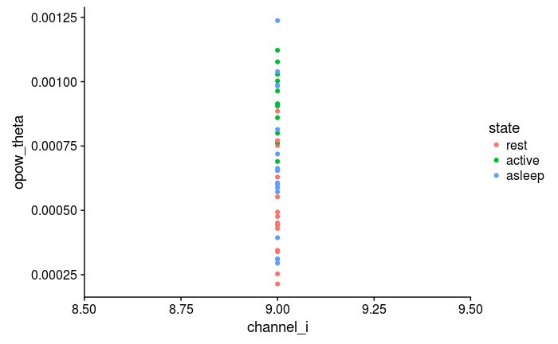

```r
albert.psddf = filter(gathered.psddf, animal == 'Albert' &
                        channel_i %in% albert.swrchannels & laser=='OFF' &
                        opow_slow != 0)
run.psddf = best.gathered.psddf %>%
  filter(state == "active")
rest.psddf = best.gathered.psddf %>%
  filter(state == "rest")
sleep.psddf = best.gathered.psddf %>%
  filter(state == 'asleep')
albert.psddf %>%
   filter(state == 'active' | state == 'asleep' | state == 'rest')  %>%
  ggplot() +
  geom_point(aes(x=channel_i, y=opow_theta, col=state))
```

```r
t.test(run.psddf$opow_theta, rest.psddf$opow_theta)
```

```
    Welch Two Sample t-test

data:  run.psddf$opow_theta and rest.psddf$opow_theta
t = 1.8551, df = 62.729, p-value = 0.06829
alternative hypothesis: true difference in means is not equal to 0
95 percent confidence interval:
 -1.181918e-05  3.174983e-04
sample estimates:
   mean of x    mean of y
0.0008641428 0.0007113032
```

```r
t.test(rest.psddf$opow_theta, sleep.psddf$opow_theta)
```

```
    Welch Two Sample t-test

data:  rest.psddf$opow_theta and sleep.psddf$opow_theta
t = -1.2322, df = 81.179, p-value = 0.2214
alternative hypothesis: true difference in means is not equal to 0
95 percent confidence interval:
 -2.376287e-04  5.586515e-05
sample estimates:
   mean of x    mean of y
0.0007113032 0.0008021850
```

Dominating frequency depending on state - theta during the run

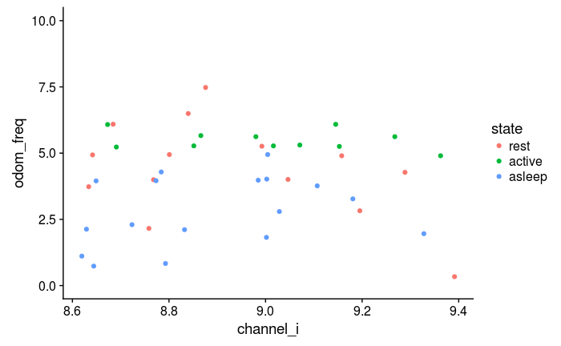

```r
albert.psddf %>%
   filter(state == 'active' | state == 'asleep' | state == 'rest')  %>%
  ggplot() +
  geom_jitter(aes(x=channel_i, y=odom_freq, col=state)) +
  ylim(c(0, 10))
```

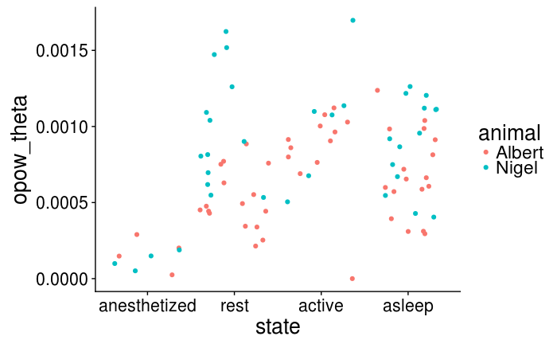

```r
best.gathered.psddf %>%
  filter(laser=='OFF') %>%
  #filter(state=='run' | state=='sleep' | state == 'run') %>%
  #filter(animal=='Albert') %>%
  ggplot() +
  geom_jitter(height=0,aes(x=state, y=opow_theta, col=animal))+
  gtheme
```

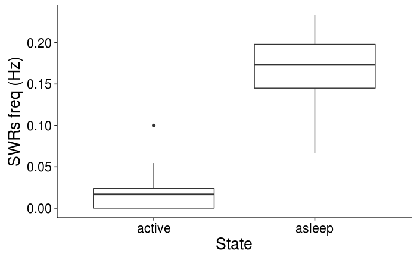

```r
best.gathered.psddf %>%
  filter(state == 'active' | state == 'asleep') %>%
  ggplot() +
  #geom_point(aes(x=state, y=oswr_freq, col=animal)) +
  geom_boxplot(aes(x=state,y=oswr_freq)) +
  ylab('SWRs freq (Hz)') +
  xlab('State') + gtheme
```

```r
t.test(run.psddf$oswr_freq, sleep.psddf$oswr_freq)
```

```
    Welch Two Sample t-test

data:  run.psddf$oswr_freq and sleep.psddf$oswr_freq
t = -20.957, df = 71.651, p-value < 2.2e-16
alternative hypothesis: true difference in means is not equal to 0
95 percent confidence interval:
 -0.1606301 -0.1327232
sample estimates:
 mean of x  mean of y
0.01969157 0.16636820
```

Explore strength of theta oscillations on the channels with SWR

```r
paired.psddf = gathered.psddf %>%
  mutate(channel_laser = paste0(channel_i, '_', laser))
paired.psddf$channel_laser = as.factor(paired.psddf$channel_laser)

albert.pow_theta = paired.psddf %>%
  filter(animal == 'Albert') %>%
  filter(state == 'asleep' )  %>%
  #filter(channel_i %in% albert.swrchannels)
  filter(channel_i == 15)
on.albert.pow_theta = subset(albert.pow_theta, laser == 'ON', opow_slow_gamma, drop=TRUE)
start.albert.pow_theta = subset(albert.pow_theta, laser == 'OFF' & time_sec == 0, opow_slow_gamma, drop=TRUE)
after.albert.pow_theta = subset(albert.pow_theta, laser == 'OFF' & time_sec != 0 & time_sec < 130, opow_slow_gamma, drop=TRUE)
on.albert.swr_freq = subset(albert.pow_theta, laser == 'ON', oswr_freq, drop=TRUE)
start.albert.swr_freq = subset(albert.pow_theta, laser == 'OFF' & time_sec == 0, oswr_freq, drop=TRUE)
pd = paired(start.albert.pow_theta, on.albert.pow_theta)
colnames(pd) = c('start', 'on')
pd = pd %>%
  filter(on != 0 & start != 0)
```

```
Setting class(x) to multiple strings ("tbl_df", "tbl", ...); result will no longer be an S4 object
```

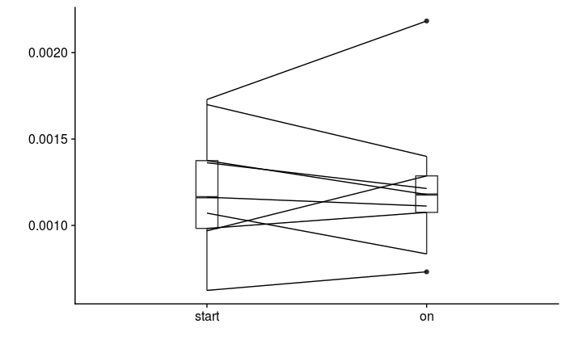

```r
with(pd, plot(paired(start, on), type = 'profile'))
```

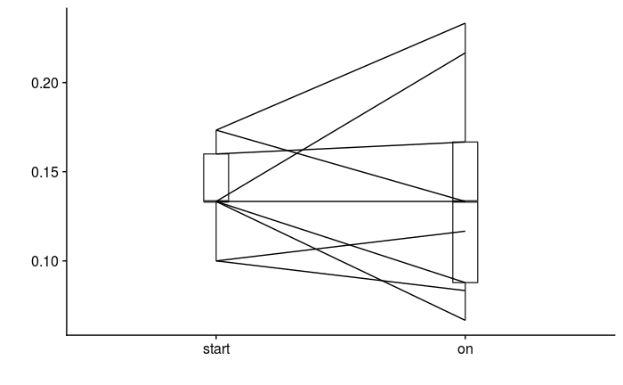

```r
pd = paired(start.albert.swr_freq, on.albert.swr_freq)
colnames(pd) = c('start', 'on')
with(pd, plot(paired(start, on), type = 'profile'))
```

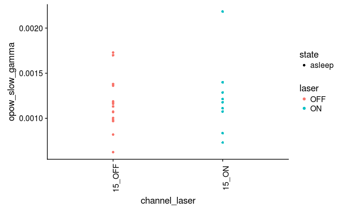

```r
#pd = paired(on.albert.pow_theta, after.albert.pow_theta)
#colnames(pd) = c('on', 'after')
#pd = pd %>%
#  filter(on < 0 & after < 0)
#with(pd, plot(paired(on, after), type = 'profile'))
ggplot(albert.pow_theta) +
  geom_point(aes(x=channel_laser, y=opow_slow_gamma, shape=state, col=laser)) +
  theme(axis.text.x = element_text(angle = 90))
```

Run paired t-test

```r
experiments_tested = gathered.psddf %>%
  filter(state == 'asleep') %>%
  #filter(animal == 'Albert') %>%
  filter(laser == 'OFF' & time_sec == 0) %>%
  #filter(odom_freq >= 4 && odom_freq <= 10) %>%
  filter(opow_theta != 0) %>%
  #filter(ohas_ripples == 0) %>%
  filter(TRUE)
ttestchannel = function(gathered.psddf, experiments_tested, ch) {
  ttestdat = gathered.psddf %>%
    filter(channel_i == ch) %>%
    filter(experiment %in% experiments_tested)
  ondat = filter(ttestdat, laser == 'ON')
  offdat = filter(ttestdat, laser == 'OFF') %>%
    filter(time_sec == 0)


  varnames = colnames(ttestdat)[8:ncol(ttestdat)]
  for (varname in varnames) {
    x = ondat[[varname]]
    x = x[!is.na(x)]
    if (varname != 'ohas_ripples' && length(x) > 0) {

      tresult = t.test(ondat[[varname]], offdat[[varname]], paired=TRUE)
      if (!is.nan(tresult$p.value) & tresult$p.value < 0.05) {
        print(paste('Channel', channel, 'Varname ', varname))
        print(tresult)

        print('% difference')
        print(tresult$estimate / mean(offdat[[varname]], na.rm=TRUE))
      }
    }
  }
}
for (channel in albert.swrchannels) {
  ttestchannel(gathered.psddf, experiments_tested$experiment, channel)
}
```

Paired t-test on a single channel

```r
experiments_tested = best.gathered.psddf %>%
  filter(laser == 'ON') %>%
  filter(opow_theta > 0.000001) %>%
  #filter(!grepl('open_field',experiment)) %>%
  filter(TRUE)
ttestdat = best.gathered.psddf %>%
  #filter((animal == 'Albert' & channel_i == albert.swrchannels[1]) |
  #         (animal == 'Nigel' & channel_i == nigel.swrchannels[1])) %>%
  #filter(animal == 'Nigel') %>%
  filter(state == 'asleep') %>%
  #filter(state == 'rest' | state == 'active') %>%
  filter(experiment %in% experiments_tested$experiment)
ondat = filter(ttestdat, laser == 'ON')
offdat = filter(ttestdat, laser == 'OFF') %>%
  filter(time_sec == 0)
varnames = colnames(ttestdat)[7:(ncol(ttestdat)-1)]
#varnames = 'opow_theta'
for (varname in varnames) {
  x = ondat[[varname]]
  x = x[!is.na(x)]
  if (varname != 'ohas_ripples' && length(x) > 0) {

    tresult = t.test(ondat[[varname]], offdat[[varname]], paired=TRUE)
    if (!is.nan(tresult$p.value) & tresult$p.value < 0.1) {
      print(paste('Varname', varname))
      print(tresult)

      print('% difference')
      print(tresult$estimate / mean(offdat[[varname]], na.rm=TRUE))
    }
  }
}
```

```
[1] "Varname oswr_freq"

    Paired t-test

data:  ondat[[varname]] and offdat[[varname]]
t = -2.2944, df = 15, p-value = 0.03662
alternative hypothesis: true difference in means is not equal to 0
95 percent confidence interval:
 -0.043512538 -0.001602342
sample estimates:
mean of the differences
            -0.02255744

[1] "% difference"
mean of the differences
             -0.1262847
[1] "Varname odom_freq"

    Paired t-test

data:  ondat[[varname]] and offdat[[varname]]
t = 2.0621, df = 15, p-value = 0.05697
alternative hypothesis: true difference in means is not equal to 0
95 percent confidence interval:
 -0.03353209  2.02638747
sample estimates:
mean of the differences
              0.9964277

[1] "% difference"
mean of the differences
              0.3889059
```

# Show some boxplots

```r
experiments_tested = best.gathered.psddf %>%
  filter(laser == 'ON') %>%
  filter(opow_theta > 0.000001) %>%
  filter(state == 'rest' | state == 'asleep')
ttestdat = subset(best.gathered.psddf,
  (experiment %in% experiments_tested$experiment) &
  (laser == 'ON' | time_sec == 0))
start.albert.swr_freq = subset(albert.pow_theta, laser == 'OFF' & time_sec == 0, oswr_freq, drop=TRUE)
ondat = filter(ttestdat, laser == 'ON')
rest.ondat = filter(ondat, state == 'rest')
asleep.ondat = filter(ondat, state == 'asleep')
offdat = filter(ttestdat, laser == 'OFF')
rest.offdat = filter(offdat, state == 'rest')
asleep.offdat = filter(offdat, state == 'asleep')
g1 = ggplot() +
  geom_boxplot(data=ttestdat, aes(x=state, y=oswr_freq, fill=laser)) +
  gtheme +
  xlab('') + ylab('Ripple incidence (Hz)') +
  theme(legend.position = 'none')
g2 = ggplot() +
  geom_boxplot(data=ttestdat, aes(x=state, y=oripple_dur, fill=laser)) +
  gtheme +
  xlab('') + ylab('Ripple duration (sec)') +
  theme(legend.position = 'none')
g3 = ggplot() +
  geom_boxplot(data=ttestdat, aes(x=state, y=oripple_peakpow, fill=laser)) +
  gtheme +
  xlab('') + ylab('Ripple peak power (a.u.)') +
  scale_fill_discrete(name = "Laser") +
  ylim(0,20)
combined_g = plot_grid(g1,g2,g3, labels = c('A','B','C'), nrow=1, ncol=3, label_size = 22, rel_widths = c(1,1,1.15))
```

```
Removed 1 rows containing non-finite values (stat_boxplot).
```

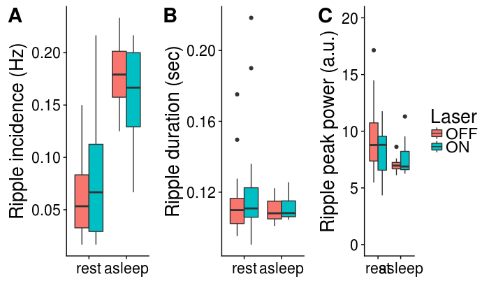

```r
combined_g
ggsave(file=paste0(img_dir, '/', 'rest_ripple_freq.svg'), plot=combined_g, width=11, height=4)
```

```r
t.test(rest.offdat$oswr_freq, rest.ondat$oswr_freq, paired=T)
```

```
    Paired t-test

data:  rest.offdat$oswr_freq and rest.ondat$oswr_freq
t = -0.97387, df = 11, p-value = 0.3511
alternative hypothesis: true difference in means is not equal to 0
95 percent confidence interval:
 -0.05405554  0.02089314
sample estimates:
mean of the differences
             -0.0165812
```

```r
t.test(asleep.offdat$oswr_freq, asleep.ondat$oswr_freq, paired=T)
```

```
    Paired t-test

data:  asleep.offdat$oswr_freq and asleep.ondat$oswr_freq
t = 2.2944, df = 15, p-value = 0.03662
alternative hypothesis: true difference in means is not equal to 0
95 percent confidence interval:
 0.001602342 0.043512538
sample estimates:
mean of the differences
             0.02255744
```

```r
t.test(rest.offdat$oripple_dur, rest.ondat$oripple_dur, paired=T)
```

```
    Paired t-test

data:  rest.offdat$oripple_dur and rest.ondat$oripple_dur
t = -0.633, df = 11, p-value = 0.5397
alternative hypothesis: true difference in means is not equal to 0
95 percent confidence interval:
 -0.04080217  0.02257504
sample estimates:
mean of the differences
           -0.009113561
```

```r
t.test(asleep.offdat$oripple_dur, asleep.ondat$oripple_dur, paired=T)
```

```
    Paired t-test

data:  asleep.offdat$oripple_dur and asleep.ondat$oripple_dur
t = -0.50877, df = 15, p-value = 0.6183
alternative hypothesis: true difference in means is not equal to 0
95 percent confidence interval:
 -0.005196896  0.003194010
sample estimates:
mean of the differences
           -0.001001443
```

```r
t.test(rest.offdat$oripple_dur, rest.ondat$oripple_dur, paired=T)
```

```
    Paired t-test

data:  rest.offdat$oripple_dur and rest.ondat$oripple_dur
t = -0.633, df = 11, p-value = 0.5397
alternative hypothesis: true difference in means is not equal to 0
95 percent confidence interval:
 -0.04080217  0.02257504
sample estimates:
mean of the differences
           -0.009113561
```

```r
t.test(asleep.offdat$oripple_dur, asleep.ondat$oripple_dur, paired=T)
```

```
    Paired t-test

data:  asleep.offdat$oripple_dur and asleep.ondat$oripple_dur
t = -0.50877, df = 15, p-value = 0.6183
alternative hypothesis: true difference in means is not equal to 0
95 percent confidence interval:
 -0.005196896  0.003194010
sample estimates:
mean of the differences
           -0.001001443
```

# Difference between channels in gamma freqs

Read in probe depths data

```r
probe_depths = read_csv('/media/prez/DATA/Prez/y-maze/probe_depths.csv')
probe_depths$channel_i = probe_depths$probe_id + 1
```

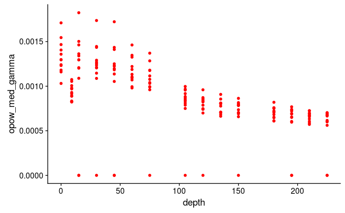

```r
gathered.psddf %>%
  filter(animal == 'Albert') %>%
  filter(state == 'active' & laser == 'OFF') %>%
  left_join(probe_depths, by='channel_i') %>%
  filter(shank == 1) %>%
  group_by(experiment) %>%
  mutate(max_slow_gamma = max(opow_slow_gamma),
         max_med_gamma = max(opow_med_gamma),
         max_fast_gamma = max(opow_fast_gamma)) %>%
  ungroup() %>%
  ggplot() +
  #geom_point(aes(x=depth, y=opow_fast_gamma / max_fast_gamma), col='blue') +
  #geom_point(aes(x=depth, y=opow_med_gamma / max_med_gamma), col='green') +
  #geom_point(aes(x=depth, y=opow_slow_gamma / max_slow_gamma), col='red')
  #geom_point(aes(x=depth, y=opow_fast_gamma), col='green')
  geom_point(aes(x=depth, y=opow_med_gamma), col='red')
```

# TODOs:

- How well do gamma cycles fit within theta: gamma-theta coherence
- ttest should be done only on a single datapoint per recording
- recheck effects!!